# Xác suất và phân bố xác suất

## Các hàm thông dụng

- `dbinom`: Binomial mass function
- `pbinom`: Binomial cumulative probability
- `qbinom`: Binomial quantiles function
- `rbinom`: Binomial random realizations
- `dpois`: Poisson mass function Section
- `ppois`: Poisson cumulative probability
- `rpois`: Poisson random realizations
- `dunif`: Uniform density function
- `punif`: Uniform cumulative probability
- `qunif`: Uniform quantiles Section
- `runif`: Uniform random realizations
- `dnorm`: Normal density function
- `pnorm`: Normal cumulative probability
- `qnorm`: Normal quantiles Section
- `rnorm`: Normal random realizations
- `qt`: Student’s t quantiles
- `dexp`: Exponential density function
- `pexp`: Exponential cumulative probability
- `qexp`: Exponential quantiles

## Bài 1: Xác xuất

Cho biết bảng phân phối xác suất sau với ứng biến ngẫu nhiên S, mô tả đánh giá cho một bộ phim.

| s | 1 | 2 | 3 | 4 | 5 |
| --- | --- | --- | --- | --- | --- |
| P(S=s) | 0.10 | 0.13 | 0.21 | ??? | 0.15 |

1. Tính $P(S = 4)$?

```r
P = 1-(0.10+0.13+0.21+0.15)
P
```

```
## [1] 0.41
```

2. Tính $P(S <= 3)$?

```r
P = 0.1+0.13+0.21
P
```

```
## [1] 0.44
```

3. Tính $mean(S)$?

```r
S <- c(0.1,0.13,0.21,0.41,0.15)
mean = function(x){
  return((1/length(x)) * sum(x))
}
mean(S)
```

```
## [1] 0.2
```

4. Tính $variance(S)$?

```r
variance = function(x){
  n = length(x)
  s = 0
  for(i in 1:n){
    s = s+(x[i]-mean(x))^2
  }
  return(s/n)
}
variance(S)
```

```
## [1] 0.01232
```

## Bài 2: Hàm mật độ và hàm phân bố tích lũy

Cho biến $W$ có hàm mật độ và hàm phân bố tích lũy như sau:

$$f(w) = \left\{
\begin{array}{ll}
\frac{w-40}{625} & \text{if } 40 \le w \le 65, \\
\frac{90-w}{625} & \text{if } 65 < w \le 90, \\
0 & \text{otherwise.}
\end{array}
\right.$$

$$F(w) = \int_{-\infty}^{w} f(u)du = \left\{
\begin{array}{ll}
0 & \text{if } w < 40, \\
\frac{w^2 - 80w + 1600}{1250} & \text{if } 40 \le w \le 65, \\
\frac{180w − w^2 − 6850}{1250} & \text{if } 65 < w \le 90, \\
1 & \text{otherwise.}
\end{array}
\right.$$

1. Viết hàm $f(w)$ trong R như định nghĩa trên với input là numeric vector $w$ theo cách vector hóa (không dùng vòng lặp).

```r
f = function(x){
  if(x>=40 & x<=65){
    return((x-40)/625)
  }
  if(x >65 & x<=90)
      return((90-w)/625)
  else
    return (0)
}
```

2. Viết hàm $F(w)$ trong R như định nghĩa trên với input là numeric vector $w$ theo cách vector hóa (không dùng vòng lặp).

```r
F = function(x){
  if (x <40)
    return(0)
  if (x>=40 & x<=65)
    return((x^2-80*x+1600)/1250)
  if (x >65 & x<=90)
    return((180*x-x^2-6850)/1250)
  else
    return((1))
}
```

```r
f(55.2)
```

```
## [1] 0.02432
```

```r
f(55.2)
```

```
## [1] 0.02432
```

4. Sử dụng hàm $F(w)$ để tính $P(W > 60)$.

```r
F(65)-F(60)+F(90)-F(65.1)
```

```
## [1] 0.676008
```

5. Sử dụng hàm $F(w)$ để tính $P(60.3 < W < 76.89)$.

```r
F(65)-F(60.3)+F(76.89)-F(65.1)
```

```
## [1] 0.5288383
```

## Bài 3: Phân bố nhị thức

Một khu bảo tồn thiên nhiên có rừng có 13 đài ngắm chim nằm rải rác khắp một khu đất rộng lớn. Các nhà tự nhiên học khẳng định rằng tại bất kỳ thời điểm nào, có 75% cơ hội nhìn thấy chim ở mỗi đài ngắm chim. Giả sử bạn đi bộ qua khu bảo tồn và ghé thăm mọi đài ngắm chim. Đặt $X$ là biến ngẫu nhiên nhị thức biểu thị tổng số ngắm chim mà ở đó bạn nhìn thấy chim.

1. Vẽ probability mass function của biến $X$.

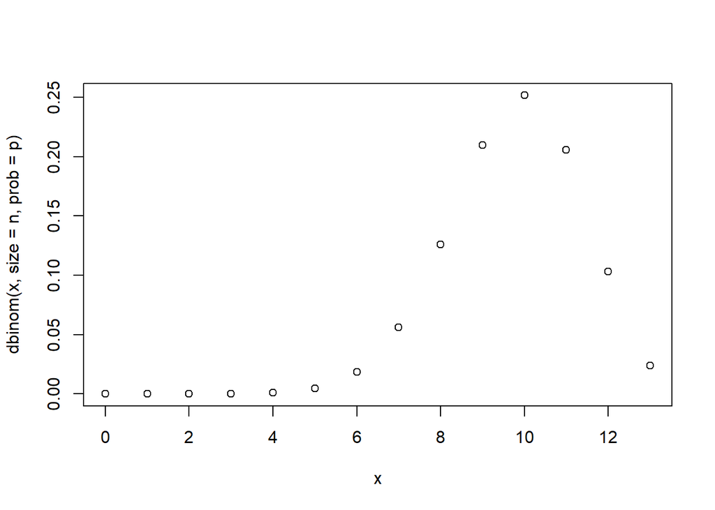

```r
n=13
p=0.75
x=0:n
plot(x,dbinom(x,size = n,prob = p))
```

b. Xác suất bạn nhìn thấy chim ở tất cả các đài ngắm chim là bao nhiêu?

```r
dbinom(13,13,0.75)
```

```
## [1] 0.02375726
```

3. Xác suất bạn nhìn thấy chim ở nhiều hơn 9 nền tảng là bao nhiêu?

```r
1 - pbinom(9,13, 0.75)
```

```
## [1] 0.5842527
```

4. Xác suất nhìn thấy chim từ 8 đến 11 đài ngắm chim là bao nhiêu? Xác định câu trả lời của bạn bằng cách chỉ sử dụng hàm `d-xxx` và `p-xxx`.

```r
pbinom(11, 13,0.75) - pbinom(7, 13, 0.75)
```

```
## [1] 0.793082
```

5. Tính giá trị trung bình và độ lệch chuẩn của biến $X$.

```r
13*0.75
```

```
## [1] 9.75
```

```r
sqrt(n*p*(1-p))
```

```
## [1] 1.561249
```

## Bài 4: Phân bố Poison

Vào mỗi thứ bảy, vào cùng một thời điểm, một người đứng bên lề đường và thống kê số lượng ô tô đi qua trong vòng 120 phút. Dựa trên kiến thức trước đây, người đó tin rằng số ô tô đi qua trung bình trong thời gian này chính xác là 107. Gọi X đại diện cho biến ngẫu nhiên Poisson mô tả số ô tô đi qua vị trí của anh ta trong mỗi buổi thứ bảy.

```r
dpois(100,107)
```

```
## [1] 0.03154021
```

2. Xác định xác suất để không có ô tô nào vượt qua.

```r
dpois(0,107)
```

```
## [1] 3.39227e-47
```

3. Vẽ đồ thị của Poisson mass function với các giá trị $60 \le x \le 150$.

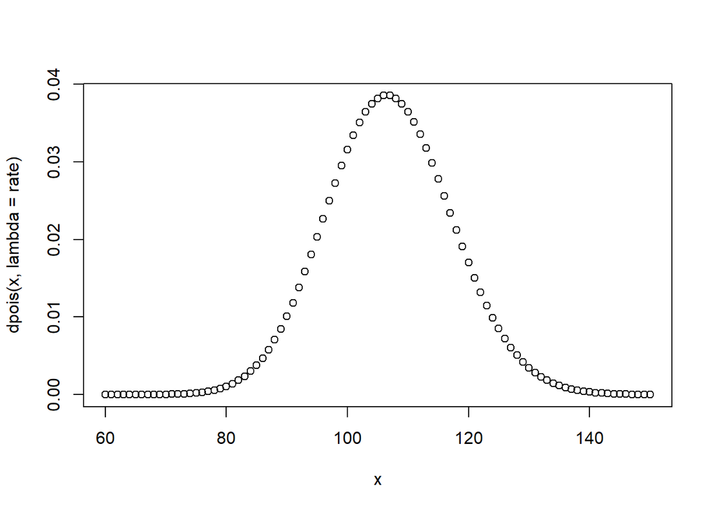

```r
rate = 107
x = 60:150
plot(x, dpois(x, lambda = rate))
```

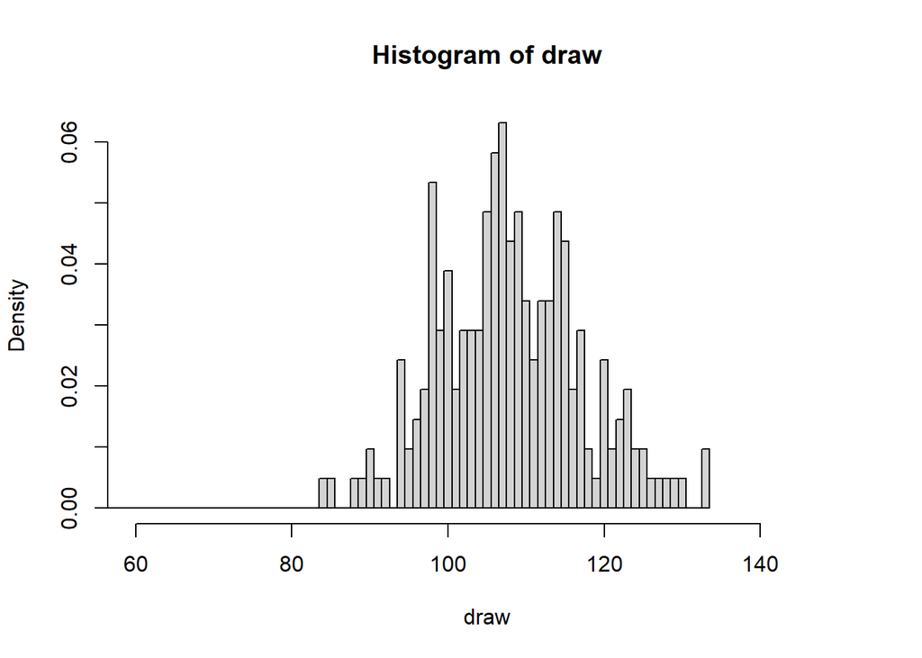

```r
draw = rpois(206, lambda = rate)
hist(draw, breaks = (0:(max(draw)+1)) - 0.5, probability = TRUE, xlim = c(60,150
                                                                          ))
```